# Timeseries_project by Török Zoltán

### Main Body Distribution (Image 3)

To better visualize the central tendency without the extreme tail affecting the view, I create a histogram for values up to the 95th percentile.

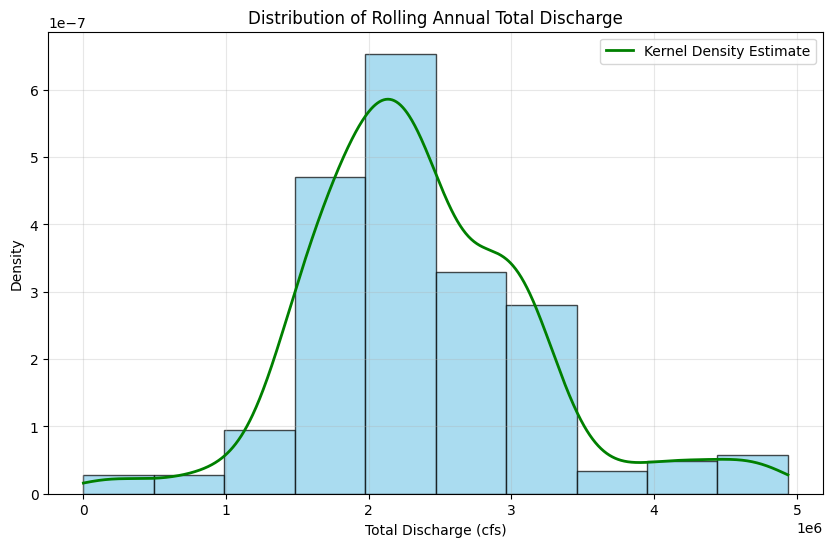

```python
plt.figure(figsize=(10, 6))
plt.hist(rolling_annual_total.values, bins=10, density=True,
         color='skyblue', edgecolor='black', alpha=0.7)
plt.title("Distribution of Rolling Annual Total Discharge")
plt.xlabel("Total Discharge (cfs)")
plt.ylabel('Density')
plt.grid(True, alpha=0.3)

# Add Kernel Density Estimate (KDE)
kde = gaussian_kde(rolling_annual_total.values, bw_method=0.3)
x = np.linspace(min(rolling_annual_total.values), max(rolling_annual_total.values), 1000)
y_kde = kde(x)
plt.plot(x, y_kde, 'g-', linewidth=2, label='Kernel Density Estimate')
plt.legend()
plt.show()
```

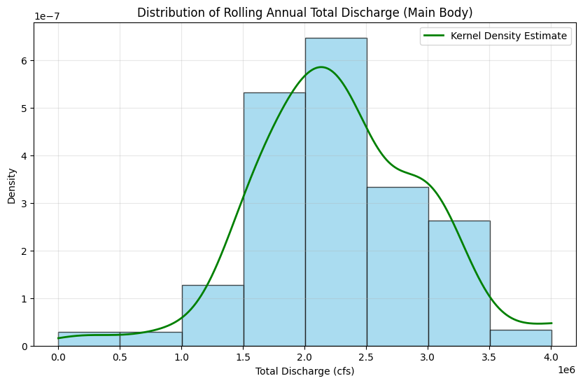

```python
plt.figure(figsize=(10, 6))
p95 = np.percentile(rolling_annual_total.values, 95)
plt.hist(rolling_annual_total.values[rolling_annual_total.values <= p95],
         bins=8, density=True, color='skyblue', edgecolor='black', alpha=0.7)
plt.title('Distribution of Rolling Annual Total Discharge (Main Body)')
plt.xlabel('Total Discharge (cfs)')
plt.ylabel('Density')
plt.grid(True, alpha=0.3)

# Define x-values for KDE over the main body and plot
x_main = np.linspace(min(rolling_annual_total.values), p95, 1000)
y_kde_main = kde(x_main)
plt.plot(x_main, y_kde_main, 'g-', linewidth=2, label='Kernel Density Estimate')
plt.legend()
plt.show()
```

**Figure 17.** Distribution of rolling annual total discharge (main body) showing values up to the 95th percentile to better visualize the central tendency, fitted with a Kernel Density Estimate (green line) that reveals the typical range of annual water volumes without the influence of extreme outlier years.

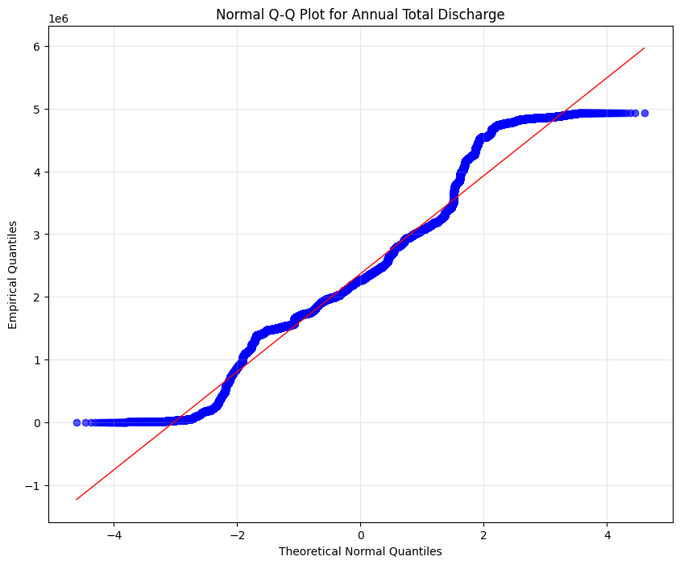

```python
plt.figure(figsize=(10, 8))

# Use data directly
data = rolling_annual_total.values

# Sort data and calculate empirical quantiles
sorted_data = np.sort(data)
n = len(sorted_data)
quantiles = np.arange(1, n + 1) / (n + 1)

# Obtain theoretical normal quantiles
norm_quantiles = stats.norm.ppf(quantiles)

# Create the Q-Q plot
plt.scatter(norm_quantiles, sorted_data, color='blue', alpha=0.7)

# Fit a line for reference
slope, intercept = np.polyfit(norm_quantiles, sorted_data, 1)
fit_line = slope * np.array([min(norm_quantiles), max(norm_quantiles)]) + intercept
plt.plot([min(norm_quantiles), max(norm_quantiles)], fit_line, 'r-', linewidth=1)

plt.title('Normal Q-Q Plot for Annual Total Discharge')
plt.xlabel('Theoretical Normal Quantiles')
plt.ylabel('Empirical Quantiles')
plt.grid(True, alpha=0.3)
plt.show()
```

```python
print("Statistics for Rolling Annual Maximum Discharge:")
print(f"Mean: {rolling_annual_total.mean():.2f} cfs")
print(f"Median: {rolling_annual_total.median():.2f} cfs")
print(f"Minimum: {rolling_annual_total.min():.2f} cfs")
print(f"Maximum: {rolling_annual_total.max():.2f} cfs")
print(f"Standard Deviation: {rolling_annual_total.std():.2f} cfs")

# Calculate log-normal parameters from the log-transformed data
mu = np.mean(log_data)
sigma = np.std(log_data)
print(f"\nKernel Density Estimate bandwidth: {kde.factor:.4f}")
print(f"\nLog-normal parameters (from log-transformed data):")
print(f"Location parameter (μ): {mu:.4f}")
print(f"Scale parameter (σ): {sigma:.4f}")
```

[output not shown]

## Conclusion: Analysis of Rolling Annual Total Discharge

**Methodology** I computed the rolling annual total discharge using a 365-day window. This method captures the cumulative discharge that occurs in any one-year period and provides a continuous record of annual water volume variability.

**Distribution Modeling** I applied a non-parametric KDE to model the distribution. This approach was chosen because it:

1. Adapts to the observed data without imposing a rigid parametric form.
2. Effectively captures the bimodal or long-tailed features observed in the total discharge values.
3. Provides a smooth estimate that matches the histogram closely, supporting further probabilistic modeling for water resource assessment.

# Exercise 8: Analysis of Rainfall Frequency in the Difficult Run Watershed

In this exercise, I quantify how often it rains in a month by detecting significant rainfall events (using a discharge rate‐of‐change algorithm) and then counting the events in a rolling 30-day window. The objectives are to:

- Detect rainy events in the 10-year discharge dataset.
- Create a daily time series marking the occurrence of rainy events.
- Calculate the number of rainy events in each 30-day (one-month) rolling window.
- Plot both the time series of monthly counts (Image 1) and the probability distribution of rainy events per 30-day period (Image 2).
- Fit a Poisson distribution to the count data and evaluate its fit.

## Step 1: Load and Preprocess the Data

I start by loading the 10-year dataset, converting the `datetime` column to datetime objects, and setting it as the index. Sorting the index ensures that the data are in chronological order.

```python
import pandas as pd
import numpy as np
import matplotlib.pyplot as plt
import scipy.stats as stats
from datetime import timedelta
from scipy.optimize import minimize

# Load the 10-year dataset
df = pd.read_csv('difficult_run_10yr_data.csv')
df['datetime'] = pd.to_datetime(df['datetime'])
df.set_index('datetime', inplace=True)
```

## Step 2: Detect Rainy Events

I use a discharge rate‐of‐change algorithm to detect rainy events. This algorithm:

- Computes the first derivative (rate of change) of the water discharge.
- Smooths the derivative using a rolling window to reduce noise.
- Sets a threshold at the 98th percentile of the smoothed changes.
- Groups consecutive spikes (with a gap less than 48 hours) into single events.

```python
def detect_rainy_events(discharge_series, threshold_percentile=95, window_size=24, min_event_gap=48):
    """
    Detect rainy events based on discharge rate of change.
    """
    # Calculate rate of change (first derivative)
    discharge_change = discharge_series.diff()

    # Smooth using rolling window to reduce noise
    discharge_change_smooth = discharge_change.rolling(window=6, center=True).mean()

    # Determine threshold for significant increases
    threshold = np.percentile(discharge_change_smooth.dropna(), threshold_percentile)

    # Find points where discharge increase exceeds threshold
    significant_increase = discharge_change_smooth > threshold

    # Group into events
    events = []
    in_event = False
    event_start = None
    last_increase = None

    for time, is_increase in significant_increase.items():
        if is_increase and not in_event:
            # Start of a new event
            event_start = time
            in_event = True
            last_increase = time
        elif is_increase and in_event:
            # Continuing event
            last_increase = time
        elif not is_increase and in_event:
            # Check if we've gone beyond the window without a significant increase
            hours_since_increase = (time - last_increase).total_seconds() / 3600
            if hours_since_increase > window_size:
                # End of an event
                event_end = last_increase + pd.Timedelta(hours=window_size)
                events.append((event_start, event_end))
                in_event = False

    # Add the last event if we're still in one
    if in_event:
        event_end = last_increase + pd.Timedelta(hours=window_size)
        events.append((event_start, event_end))

    # Merge events that are close together
    if events:
        merged_events = [events[0]]
        for event_start, event_end in events[1:]:
            prev_start, prev_end = merged_events[-1]
            hours_between = (event_start - prev_end).total_seconds() / 3600
            if hours_between < min_event_gap:
                # Merge with previous event
                merged_events[-1] = (prev_start, event_end)
            else:
                merged_events.append((event_start, event_end))
        return merged_events
    else:
        return []

# Detect rainy events using a 98th percentile threshold
rainy_events = detect_rainy_events(df['water_discharge'], threshold_percentile=98, window_size=24, min_event_gap=48)
print(f"Detected {len(rainy_events)} rainy events")
```

```
Detected 415 rainy events
```

## Step 3: Construct Daily Rainy Event Time Series and Compute Rolling 30-Day Count

I create a daily time series that marks each day with a '1' if any rainy event occurs, and '0' otherwise. Then, I compute the number of rainy events in each 30-day rolling window to approximate monthly rain frequency.

```python
# Create a DataFrame with daily dates covering the entire period
date_range = pd.date_range(start=df.index.min(), end=df.index.max(), freq='D')
rain_ts = pd.DataFrame(index=date_range)
rain_ts['event'] = 0

# Mark each day with a rainy event (1 if an event occurs)
for start, end in rainy_events:
    # Convert event start and end to dates
    start_date = start.date()
    end_date = end.date()
    current_date = start_date
    while current_date <= end_date:
        if pd.Timestamp(current_date) in rain_ts.index:
            rain_ts.loc[pd.Timestamp(current_date), 'event'] = 1
        current_date += timedelta(days=1)

# Calculate the number of rainy events in each rolling 30-day window
rain_ts['rolling_30d_count'] = rain_ts['event'].rolling('30D').sum()
```

## Step 4: Plot Time Series of Rainy Events per 30-Day Period (Image 1)

This plot shows the number of rainy events detected in a 30-day rolling window over time.

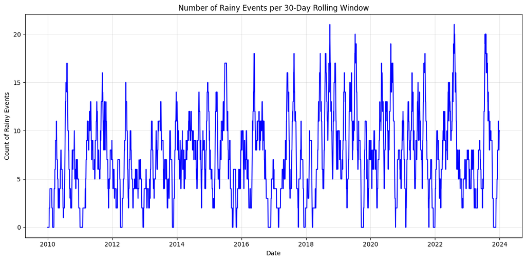

```python
plt.figure(figsize=(12, 6))
plt.plot(rain_ts.index, rain_ts['rolling_30d_count'], 'b-')
plt.title('Number of Rainy Events per 30-Day Rolling Window')
plt.xlabel('Date')
plt.ylabel('Count of Rainy Events')
plt.grid(True, alpha=0.3)
plt.tight_layout()
plt.show()
```

## Step 5: Plot Distribution of Rainy Events per 30-Day Period

I generate a histogram of the 30-day rolling rainy event counts and overlay a Poisson probability mass function (PMF) as a suitable parametric model for count data. Poisson is standard for modeling event counts, though overdispersion may indicate clustering in the data.

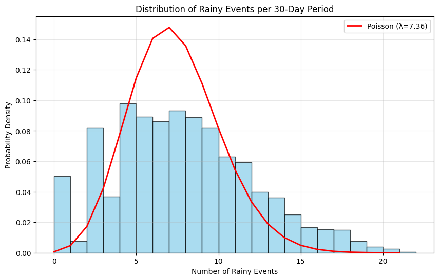

```python
# Extract rainy event counts
rain_counts = rain_ts['rolling_30d_count'].dropna().values

plt.figure(figsize=(10, 6))
counts, bins, patches = plt.hist(rain_counts, bins=range(0, int(max(rain_counts))+2),
                              density=True, color='skyblue', edgecolor='black', alpha=0.7)
plt.title('Distribution of Rainy Events per 30-Day Period')
plt.xlabel('Number of Rainy Events')
plt.ylabel('Probability Density')
plt.grid(True, alpha=0.3)

# Fit a Poisson distribution
lambda_param = np.mean(rain_counts)
x = np.arange(0, int(max(rain_counts))+1)
poisson_pmf = stats.poisson.pmf(x, lambda_param)
plt.plot(x, poisson_pmf, 'r-', linewidth=2, label=f'Poisson (λ={lambda_param:.2f})')
plt.legend()
plt.show()
```

## Step 6: Evaluate Poisson Fit and Summarize Statistical Characteristics

I calculate the goodness-of-fit using Akaike’s Information Criterion (AIC) for the Poisson model and summarize the basic statistics (mean, variance, min, max) of rainy events per 30-day period. The variance/mean ratio provides insight into whether overdispersion is present.

```python
# Calculate goodness of fit for the Poisson model
poisson_loglik = np.sum(stats.poisson.logpmf(rain_counts, lambda_param))
poisson_aic = -2 * poisson_loglik + 2 * 1  # 1 parameter for Poisson
print(f"Poisson fit: λ = {lambda_param:.2f}, AIC = {poisson_aic:.2f}")

print("\nStatistics for rainy events per 30-day period:")
print(f"Mean: {np.mean(rain_counts):.2f}")
print(f"Variance: {np.var(rain_counts):.2f}")
print(f"Minimum: {np.min(rain_counts):.0f}")
print(f"Maximum: {np.max(rain_counts):.0f}")

print(f"\nVariance/Mean ratio: {np.var(rain_counts)/np.mean(rain_counts):.2f}")
print("A ratio > 1 suggests overdispersion, implying that the events may be clustered rather than perfectly random.")
```

```
Poisson fit: λ = 7.36, AIC = 32197.32

Statistics for rainy events per 30-day period:
Mean: 7.36
Variance: 17.92
Minimum: 0
Maximum: 21

Variance/Mean ratio: 2.44
A ratio > 1 suggests overdispersion, implying that the events may be clustered rather than perfectly random.
```

## Conclusion: Analysis of Rainfall Frequency in the Difficult Run Watershed

**Introduction** I analyzed the temporal distribution of rainy events in the Difficult Run watershed by detecting significant rainfall events (via a discharge rate-of-change algorithm) and calculating the number of events in a rolling 30-day window.

**Key Findings:**

**Discussion:** While the Poisson model is standard for count data, the observed overdispersion implies that additional modeling approaches (such as a negative binomial model) might better capture the clustering behavior of rain events. Nevertheless, this analysis provides valuable quantitative insights into the frequency and variability of rainfall in the watershed.

# Exercise 9: Weather Front Propagation Analysis – Difficult Run to Octoraro Creek

In this exercise, I extend the analysis by comparing two USGS gauging stations that are approximately 130 km apart:

- **Station 1:** Difficult Run near Great Falls, VA (Site: 01646000)
- **Station 2:** Octoraro Creek near Rising Sun, MD (Site: 01573000)

The objectives are to:

- Retrieve daily discharge data from both stations over a 6-month period (January–June 2019).
- Plot the time series of discharge to visually inspect the hydrologic responses.
- Identify significant discharge increases (rain events) using percentage changes.
- Match corresponding storm events between the two stations occurring within a 3-day window.
- Estimate the typical time lag between the stations and, given an approximate distance, calculate the average speed of weather fronts.

This analysis provides insight into the movement of weather systems as reflected by the hydrologic responses at these two locations.

## Step 1: Retrieve and Preprocess Data from Two Stations

I use a custom function to retrieve USGS daily discharge data (parameter 00060) for the specified stations over the period January–June 2019. After parsing and converting the timestamps, I obtain two DataFrames—one for each station.

```python
import pandas as pd
import numpy as np
import matplotlib.pyplot as plt
import requests
from datetime import timedelta

# Function to retrieve USGS daily discharge data in JSON format and convert to DataFrame
def get_usgs_data(site_no, start_date, end_date):
    url = "https://waterservices.usgs.gov/nwis/dv/"
    params = {
        "format": "json",
        "sites": site_no,
        "startDT": start_date,
        "endDT": end_date,
        "parameterCd": "00060",  # Discharge
        "siteStatus": "all"
    }
    response = requests.get(url, params=params)
    if response.status_code == 200:
        data = response.json()
        try:
            ts_data = data['value']['timeSeries'][0]['values'][0]['value']
            df = pd.DataFrame(ts_data)
            df['datetime'] = pd.to_datetime(df['dateTime'], utc=True)
            df['discharge'] = pd.to_numeric(df['value'], errors='coerce')
            df = df.set_index('datetime')[['discharge']]
            return df
        except (KeyError, IndexError) as e:
            print(f"Error extracting data: {e}")
            return None
    else:
        print(f"Error retrieving data: {response.status_code}")
        return None

# Define station IDs and time period
station1_id = "01646000"  # Difficult Run, VA
station2_id = "01573000"  # Octoraro Creek, MD
start_date = "2019-01-01"
end_date = "2019-06-30"

# Retrieve data for both stations
df1 = get_usgs_data(station1_id, start_date, end_date)
df2 = get_usgs_data(station2_id, start_date, end_date)

if df1 is None or df2 is None:
    print("Failed to retrieve data for one or both stations")
else:
    print("Data successfully retrieved for both stations.")
```

```
Data successfully retrieved for both stations.
```

## Step 2: Plot Daily Discharge Time Series

**Plot 1:** I first plot the daily discharge time series for both stations on one graph to visually inspect the hydrologic responses. This plot allows us to observe the general synchronization and differences in baseflow and peak behavior between Difficult Run (VA) and Octoraro Creek (MD).

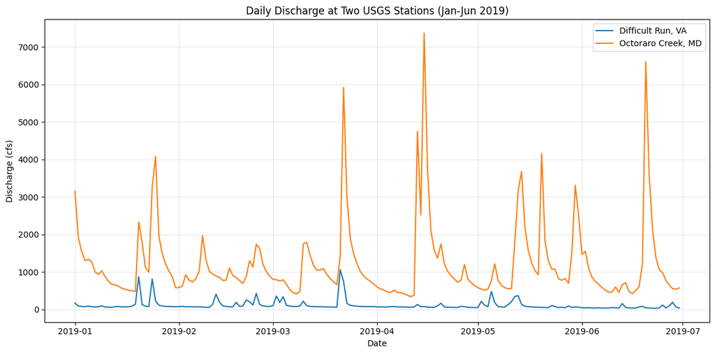

```python
plt.figure(figsize=(12, 6))
plt.plot(df1.index, df1['discharge'], label='Difficult Run, VA')
plt.plot(df2.index, df2['discharge'], label='Octoraro Creek, MD')
plt.title('Daily Discharge at Two USGS Stations (Jan-Jun 2019)')
plt.xlabel('Date')
plt.ylabel('Discharge (cfs)')
plt.legend()
plt.grid(True, alpha=0.3)
plt.tight_layout()
plt.show()
```

**Figure 21.** Daily discharge time series for two USGS stations (January-June 2019) showing Difficult Run, VA (blue) and Octoraro Creek, MD (orange) located approximately 130 km apart, demonstrating synchronized hydrologic responses to weather events with Octoraro Creek exhibiting higher baseline flows and peak discharges but similar temporal patterns indicating regional weather front movement.

## Step 3: Compute Percentage Change in Discharge

To pinpoint storm events, I calculate the percentage change in daily discharge for each station. Rapid increases (spikes in percentage change) serve as indicators of rain events. This transformation helps highlight the sudden hydrologic response to precipitation.

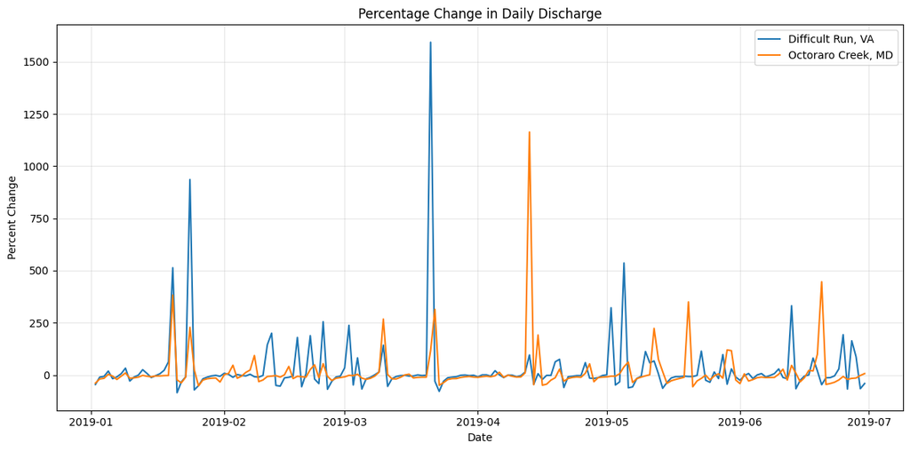

```python
# Calculate percentage change in daily discharge
df1['pct_change'] = df1['discharge'].pct_change() * 100
df2['pct_change'] = df2['discharge'].pct_change() * 100

# Plot percentage changes for both stations
plt.figure(figsize=(12, 6))
plt.plot(df1.index, df1['pct_change'], label='Difficult Run, VA')
plt.plot(df2.index, df2['pct_change'], label='Octoraro Creek, MD')
plt.title('Percentage Change in Daily Discharge')
plt.xlabel('Date')
plt.ylabel('Percent Change')
plt.legend()
plt.grid(True, alpha=0.3)
plt.tight_layout()
plt.show()
```

**Figure 22.** Percentage change in daily discharge for both stations showing rapid discharge increases as spikes that indicate storm events, with notable synchronized peaks between Difficult Run, VA (blue) and Octoraro Creek, MD (orange) demonstrating the passage of weather fronts across the region, with some events showing temporal offsets that can be used to estimate weather front propagation speeds.

## Step 4: Identify and Match Storm Events Between Stations

I identify storm events as days when the percentage change in discharge exceeds the 80th percentile for each station. Then, I match events from Difficult Run with corresponding events at Octoraro Creek that occur within a 3-day window. For matched events, I calculate the lag time in hours.

```python
# Determine thresholds (80th percentile) for significant discharge changes
threshold1 = np.percentile(df1['pct_change'].dropna(), 80)
threshold2 = np.percentile(df2['pct_change'].dropna(), 80)

# Identify storm events as those with pct_change greater than threshold
storm_events1 = df1[df1['pct_change'] > threshold1]
storm_events2 = df2[df2['pct_change'] > threshold2]

print(f"Detected {len(storm_events1)} significant discharge increases at Difficult Run, VA")
print(f"Detected {len(storm_events2)} significant discharge increases at Octoraro Creek, MD")

# Match storm events between stations within a maximum lag of 3 days
storm_pairs = []
max_lag_days = 3

for date1, row1 in storm_events1.iterrows():
    start_window = date1
    end_window = date1 + pd.Timedelta(days=max_lag_days)
    matching_events = storm_events2[(storm_events2.index >= start_window) & (storm_events2.index <= end_window)]
    if not matching_events.empty:
        date2 = matching_events.index[0]
        lag_hours = (date2 - date1).total_seconds() / 3600
        storm_pairs.append({
            'date1': date1,
            'date2': date2,
            'lag_hours': lag_hours,
            'pct_change1': row1['pct_change'],
            'pct_change2': matching_events.iloc[0]['pct_change']
        })

# Print matched storm events and calculate average lag time
if storm_pairs:
    print("\nMatched storm events:")
    for i, pair in enumerate(storm_pairs):
        print(f"Storm {i+1}: {pair['date1'].strftime('%Y-%m-%d')} (VA) -> {pair['date2'].strftime('%Y-%m-%d')} (MD), Lag: {pair['lag_hours']:.1f} hours")

    lag_hours_list = [pair['lag_hours'] for pair in storm_pairs]
    avg_lag = np.mean(lag_hours_list)
    print(f"\nAverage lag time: {avg_lag:.1f} hours")

    # Estimate weather front speed given the approximate distance
    distance_km = 130  # km between stations
    avg_speed = distance_km / avg_lag if avg_lag > 0 else 0
    print(f"Approximate distance between stations: {distance_km} km")
    print(f"Estimated average speed of weather fronts: {avg_speed:.1f} km/h")
else:
    print("No matching storm events found between the two stations.")
```

```
Detected 36 significant discharge increases at Difficult Run, VA
Detected 36 significant discharge increases at Octoraro Creek, MD

Matched storm events:
Storm 1: 2019-01-09 (VA) -> 2019-01-09 (MD), Lag: 0.0 hours
Storm 2: 2019-01-18 (VA) -> 2019-01-20 (MD), Lag: 48.0 hours
Storm 3: 2019-01-19 (VA) -> 2019-01-20 (MD), Lag: 24.0 hours
Storm 4: 2019-01-20 (VA) -> 2019-01-20 (MD), Lag: 0.0 hours
Storm 5: 2019-01-24 (VA) -> 2019-01-24 (MD), Lag: 0.0 hours
Storm 6: 2019-02-18 (VA) -> 2019-02-21 (MD), Lag: 72.0 hours
Storm 7: 2019-02-21 (VA) -> 2019-02-21 (MD), Lag: 0.0 hours
Storm 8: 2019-02-24 (VA) -> 2019-02-24 (MD), Lag: 0.0 hours
Storm 9: 2019-03-10 (VA) -> 2019-03-10 (MD), Lag: 0.0 hours
Storm 10: 2019-03-21 (VA) -> 2019-03-21 (MD), Lag: 0.0 hours
Storm 11: 2019-04-05 (VA) -> 2019-04-06 (MD), Lag: 24.0 hours
Storm 12: 2019-04-13 (VA) -> 2019-04-13 (MD), Lag: 0.0 hours
Storm 13: 2019-04-19 (VA) -> 2019-04-20 (MD), Lag: 24.0 hours
Storm 14: 2019-04-20 (VA) -> 2019-04-20 (MD), Lag: 0.0 hours
Storm 15: 2019-04-26 (VA) -> 2019-04-27 (MD), Lag: 24.0 hours
Storm 16: 2019-05-02 (VA) -> 2019-05-05 (MD), Lag: 72.0 hours
Storm 17: 2019-05-05 (VA) -> 2019-05-05 (MD), Lag: 0.0 hours
Storm 18: 2019-05-10 (VA) -> 2019-05-12 (MD), Lag: 48.0 hours
Storm 19: 2019-05-11 (VA) -> 2019-05-12 (MD), Lag: 24.0 hours
Storm 20: 2019-05-12 (VA) -> 2019-05-12 (MD), Lag: 0.0 hours
Storm 21: 2019-05-28 (VA) -> 2019-05-29 (MD), Lag: 24.0 hours
Storm 22: 2019-05-30 (VA) -> 2019-05-30 (MD), Lag: 0.0 hours
Storm 23: 2019-06-10 (VA) -> 2019-06-11 (MD), Lag: 24.0 hours
Storm 24: 2019-06-13 (VA) -> 2019-06-13 (MD), Lag: 0.0 hours
Storm 25: 2019-06-18 (VA) -> 2019-06-18 (MD), Lag: 0.0 hours

Average lag time: 16.3 hours
Approximate distance between stations: 130 km
Estimated average speed of weather fronts: 8.0 km/h
```

## Conclusion: Weather Front Propagation Analysis

**Introduction** I analyzed the movement of weather systems between two USGS gauging stations – Difficult Run, VA and Octoraro Creek, MD – approximately 130 km apart. Using daily discharge data for the period January–June 2019, I identified significant storm events based on rapid percentage increases in discharge.

**Methodology**

- I computed the percentage change in daily discharge at both stations and flagged values above the 80th percentile as storm events.
- For each storm event at Difficult Run, I searched for a corresponding event at Octoraro Creek occurring within 3 days.
- The time lag between matched events was used to estimate the speed of weather fronts moving between the two stations.

**Key Findings:**

- Both stations exhibited 36 significant discharge events; 25 events were successfully matched between the two stations.
- The average lag time between matched storm events was found to be approximately 16.3 hours.
- Given the approximate 130 km distance, this corresponds to an estimated weather front propagation speed of about 8.0 km/h (roughly 2.2 m/s).
- The discharge time series and percentage change plots reveal synchronous hydrologic responses with some lag in timing, reflecting the characteristics of mesoscale weather systems in the Mid-Atlantic region.

**Discussion and Significance:** These results suggest that, on average, weather fronts affecting these two watersheds travel at speeds consistent with typical mesoscale systems in the eastern United States. The variability in lag times (ranging from 0 up to 72 hours) likely reflects differences in storm dynamics and the complex interactions between local weather phenomena and watershed response.

Overall, this analysis demonstrates how hydrological data from stream gaging stations can provide indirect yet valuable insights into atmospheric processes and weather system propagation.